# Risk Factor Analysis

## Outcome Variable

**Outcome Variable:** whz

## Predictor Variables

**Intervention Variable:** mwtkg

**Adjustment Set:**

- arm
- W_mage
- W_fage
- meducyrs
- feducyrs
- single
- brthmon
- W_gagebrth
- W_birthwt
- W_birthlen
- vagbrth
- delta_W_mage
- delta_W_fage
- delta_meducyrs
- delta_feducyrs
- delta_single
- delta_brthmon
- delta_W_gagebrth
- delta_W_birthwt
- delta_W_birthlen
- delta_vagbrth

## Stratifying Variables

The analysis was stratified on these variable(s):

- agecat
- studyid
- country

## Data Summary

| agecat | studyid | country | mwtkg | n_cell | n |
| --- | --- | --- | --- | --- | --- |
| 6 months | LCNI-5 | MALAWI | >=58 kg | 114 | 837 |
| 6 months | LCNI-5 | MALAWI | <52 kg | 504 | 837 |
| 6 months | LCNI-5 | MALAWI | [52-58) kg | 219 | 837 |
| 6 months | MAL-ED | BANGLADESH | >=58 kg | 46 | 241 |
| 6 months | MAL-ED | BANGLADESH | <52 kg | 154 | 241 |
| 6 months | MAL-ED | BANGLADESH | [52-58) kg | 41 | 241 |
| 6 months | MAL-ED | BRAZIL | >=58 kg | 137 | 208 |
| 6 months | MAL-ED | BRAZIL | <52 kg | 37 | 208 |
| 6 months | MAL-ED | BRAZIL | [52-58) kg | 34 | 208 |
| 6 months | MAL-ED | INDIA | >=58 kg | 40 | 235 |
| 6 months | MAL-ED | INDIA | <52 kg | 146 | 235 |
| 6 months | MAL-ED | INDIA | [52-58) kg | 49 | 235 |
| 6 months | MAL-ED | NEPAL | >=58 kg | 79 | 236 |
| 6 months | MAL-ED | NEPAL | <52 kg | 75 | 236 |
| 6 months | MAL-ED | NEPAL | [52-58) kg | 82 | 236 |
| 6 months | MAL-ED | PERU | >=58 kg | 100 | 272 |
| 6 months | MAL-ED | PERU | <52 kg | 107 | 272 |
| 6 months | MAL-ED | PERU | [52-58) kg | 65 | 272 |
| 6 months | MAL-ED | SOUTH AFRICA | >=58 kg | 179 | 249 |
| 6 months | MAL-ED | SOUTH AFRICA | <52 kg | 29 | 249 |
| 6 months | MAL-ED | SOUTH AFRICA | [52-58) kg | 41 | 249 |
| 6 months | MAL-ED | TANZANIA, UNITED REPUBLIC OF | >=58 kg | 94 | 247 |
| 6 months | MAL-ED | TANZANIA, UNITED REPUBLIC OF | <52 kg | 95 | 247 |
| 6 months | MAL-ED | TANZANIA, UNITED REPUBLIC OF | [52-58) kg | 58 | 247 |
| 6 months | NIH-Birth | BANGLADESH | >=58 kg | 71 | 537 |
| 6 months | NIH-Birth | BANGLADESH | <52 kg | 385 | 537 |
| 6 months | NIH-Birth | BANGLADESH | [52-58) kg | 81 | 537 |
| 6 months | NIH-Crypto | BANGLADESH | >=58 kg | 184 | 715 |
| 6 months | NIH-Crypto | BANGLADESH | <52 kg | 383 | 715 |
| 6 months | NIH-Crypto | BANGLADESH | [52-58) kg | 148 | 715 |

[output cut: 57 more lines]

The following strata were considered:

- agecat: 24 months, studyid: LCNI-5, country: MALAWI
- agecat: 24 months, studyid: MAL-ED, country: BANGLADESH
- agecat: 24 months, studyid: MAL-ED, country: BRAZIL
- agecat: 24 months, studyid: MAL-ED, country: INDIA
- agecat: 24 months, studyid: MAL-ED, country: NEPAL
- agecat: 24 months, studyid: MAL-ED, country: PERU
- agecat: 24 months, studyid: MAL-ED, country: SOUTH AFRICA
- agecat: 24 months, studyid: MAL-ED, country: TANZANIA, UNITED REPUBLIC OF
- agecat: 24 months, studyid: NIH-Birth, country: BANGLADESH
- agecat: 24 months, studyid: NIH-Crypto, country: BANGLADESH
- agecat: 24 months, studyid: PROBIT, country: BELARUS
- agecat: 24 months, studyid: PROVIDE, country: BANGLADESH
- agecat: 24 months, studyid: TanzaniaChild2, country: TANZANIA, UNITED REPUBLIC OF
- agecat: 24 months, studyid: ZVITAMBO, country: ZIMBABWE
- agecat: 6 months, studyid: LCNI-5, country: MALAWI
- agecat: 6 months, studyid: MAL-ED, country: BANGLADESH
- agecat: 6 months, studyid: MAL-ED, country: BRAZIL
- agecat: 6 months, studyid: MAL-ED, country: INDIA
- agecat: 6 months, studyid: MAL-ED, country: NEPAL
- agecat: 6 months, studyid: MAL-ED, country: PERU
- agecat: 6 months, studyid: MAL-ED, country: SOUTH AFRICA
- agecat: 6 months, studyid: MAL-ED, country: TANZANIA, UNITED REPUBLIC OF
- agecat: 6 months, studyid: NIH-Birth, country: BANGLADESH
- agecat: 6 months, studyid: NIH-Crypto, country: BANGLADESH
- agecat: 6 months, studyid: PROBIT, country: BELARUS
- agecat: 6 months, studyid: PROVIDE, country: BANGLADESH
- agecat: 6 months, studyid: SAS-CompFeed, country: INDIA
- agecat: 6 months, studyid: TanzaniaChild2, country: TANZANIA, UNITED REPUBLIC OF
- agecat: 6 months, studyid: ZVITAMBO, country: ZIMBABWE

### Dropped Strata

Some strata were dropped due to rare outcomes:

- agecat: 24 months, studyid: TanzaniaChild2, country: TANZANIA, UNITED REPUBLIC OF

## Methods Detail

We’re interested in the causal parameters $E[Y_a]$ for all values of $a \in \mathcal{A}$. These parameters represent the mean outcome if, possibly contrary to fact, we intervened to set all units to have $A=a$. Under the randomization and positivity assumptions, these are identified by the statistical parameters $\psi_a=E_W[E_{Y|A,W}(Y|A=a,W)]$. In addition, we’re interested in the mean of $Y$, $E[Y]$ under no intervention (the observed mean). We will estimate these parameters by using SuperLearner to fit the relevant likelihood factors – $E_{Y|A,W}(Y|A=a,W)$ and $p(A=a|W)$, and then updating our likelihood fit using a joint TMLE.

For unadjusted analyses ($W=\{\}$), initial likelihoods were estimated using Lrnr_glm to estimate the simple $E(Y|A)$ and Lrnr_mean to estimate $p(A)$. For adjusted analyses, a small library containing Lrnr_glmnet, Lrnr_xgboost, and Lrnr_mean was used.

Having estimated these parameters, we will then use the delta method to estimate relative risks and attributable risks relative to a prespecified baseline level of $A$.

# Results Detail

## Results Plots

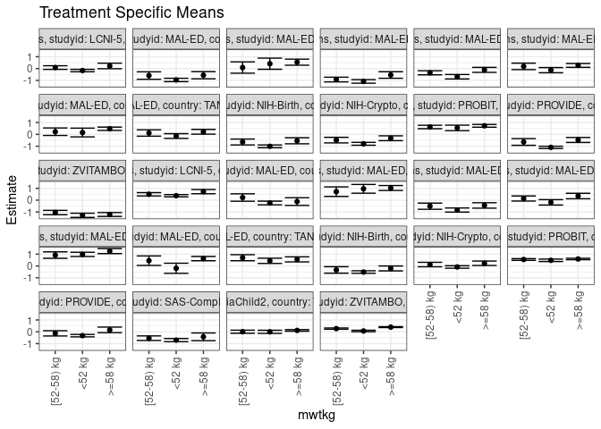

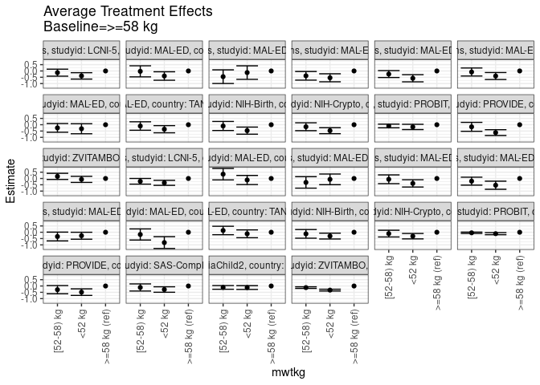

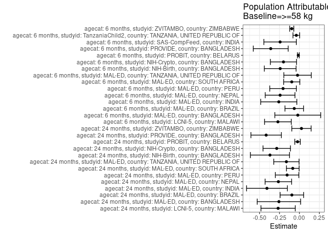

## Results Table

### Parameter: TSM

| agecat | studyid | country | intervention_level | baseline_level | estimate | ci_lower | ci_upper |
| --- | --- | --- | --- | --- | --- | --- | --- |
| 6 months | LCNI-5 | MALAWI | >=58 kg | NA | 0.7214327 | 0.5449442 | 0.8979213 |
| 6 months | LCNI-5 | MALAWI | <52 kg | NA | 0.3791476 | 0.2850249 | 0.4732704 |
| 6 months | LCNI-5 | MALAWI | [52-58) kg | NA | 0.4975731 | 0.3582730 | 0.6368733 |
| 6 months | MAL-ED | BANGLADESH | >=58 kg | NA | -0.1171176 | -0.4423738 | 0.2081385 |
| 6 months | MAL-ED | BANGLADESH | <52 kg | NA | -0.2368706 | -0.3914255 | -0.0823157 |
| 6 months | MAL-ED | BANGLADESH | [52-58) kg | NA | 0.2246836 | -0.0910147 | 0.5403819 |
| 6 months | MAL-ED | BRAZIL | >=58 kg | NA | 1.0297484 | 0.8205678 | 1.2389289 |
| 6 months | MAL-ED | BRAZIL | <52 kg | NA | 0.9601882 | 0.5913454 | 1.3290310 |
| 6 months | MAL-ED | BRAZIL | [52-58) kg | NA | 0.7191196 | 0.3155330 | 1.1227062 |
| 6 months | MAL-ED | INDIA | >=58 kg | NA | -0.4448801 | -0.6749639 | -0.2147963 |
| 6 months | MAL-ED | INDIA | <52 kg | NA | -0.8333998 | -1.0074879 | -0.6593116 |
| 6 months | MAL-ED | INDIA | [52-58) kg | NA | -0.5091289 | -0.7694241 | -0.2488338 |
| 6 months | MAL-ED | NEPAL | >=58 kg | NA | 0.3524202 | 0.1224113 | 0.5824291 |
| 6 months | MAL-ED | NEPAL | <52 kg | NA | -0.1819229 | -0.4095858 | 0.0457399 |
| 6 months | MAL-ED | NEPAL | [52-58) kg | NA | 0.1402441 | -0.0749112 | 0.3553995 |
| 6 months | MAL-ED | PERU | >=58 kg | NA | 1.2598477 | 1.0485404 | 1.4711550 |
| 6 months | MAL-ED | PERU | <52 kg | NA | 0.9834560 | 0.8037913 | 1.1631206 |
| 6 months | MAL-ED | PERU | [52-58) kg | NA | 0.9220353 | 0.6496790 | 1.1943915 |
| 6 months | MAL-ED | SOUTH AFRICA | >=58 kg | NA | 0.6251983 | 0.4438712 | 0.8065254 |
| 6 months | MAL-ED | SOUTH AFRICA | <52 kg | NA | -0.1936433 | -0.6230132 | 0.2357267 |
| 6 months | MAL-ED | SOUTH AFRICA | [52-58) kg | NA | 0.4482129 | 0.0473267 | 0.8490991 |
| 6 months | MAL-ED | TANZANIA, UNITED REPUBLIC OF | >=58 kg | NA | 0.5598644 | 0.3448801 | 0.7748487 |
| 6 months | MAL-ED | TANZANIA, UNITED REPUBLIC OF | <52 kg | NA | 0.4365343 | 0.2142709 | 0.6587976 |
| 6 months | MAL-ED | TANZANIA, UNITED REPUBLIC OF | [52-58) kg | NA | 0.6991484 | 0.4439285 | 0.9543682 |
| 6 months | NIH-Birth | BANGLADESH | >=58 kg | NA | -0.2064685 | -0.4130651 | 0.0001281 |
| 6 months | NIH-Birth | BANGLADESH | <52 kg | NA | -0.5110213 | -0.6162207 | -0.4058220 |
| 6 months | NIH-Birth | BANGLADESH | [52-58) kg | NA | -0.3342336 | -0.6091285 | -0.0593388 |
| 6 months | NIH-Crypto | BANGLADESH | >=58 kg | NA | 0.2296894 | 0.0422571 | 0.4171216 |
| 6 months | NIH-Crypto | BANGLADESH | <52 kg | NA | -0.0832573 | -0.1868468 | 0.0203322 |
| 6 months | NIH-Crypto | BANGLADESH | [52-58) kg | NA | 0.1222366 | -0.0666333 | 0.3111064 |

[output cut: 54 more lines]

### Parameter: E(Y)

| agecat | studyid | country | intervention_level | baseline_level | estimate | ci_lower | ci_upper |
| --- | --- | --- | --- | --- | --- | --- | --- |
| 6 months | LCNI-5 | MALAWI | NA | NA | 0.4518519 | 0.3806435 | 0.5230602 |
| 6 months | MAL-ED | BANGLADESH | NA | NA | -0.1376763 | -0.2664642 | -0.0088885 |
| 6 months | MAL-ED | BRAZIL | NA | NA | 0.9648518 | 0.8004118 | 1.1292917 |
| 6 months | MAL-ED | INDIA | NA | NA | -0.7034149 | -0.8300527 | -0.5767771 |
| 6 months | MAL-ED | NEPAL | NA | NA | 0.1104308 | -0.0208643 | 0.2417259 |
| 6 months | MAL-ED | PERU | NA | NA | 1.0548591 | 0.9328922 | 1.1768259 |
| 6 months | MAL-ED | SOUTH AFRICA | NA | NA | 0.5291499 | 0.3751396 | 0.6831602 |
| 6 months | MAL-ED | TANZANIA, UNITED REPUBLIC OF | NA | NA | 0.5362213 | 0.4049390 | 0.6675036 |
| 6 months | NIH-Birth | BANGLADESH | NA | NA | -0.4474038 | -0.5378167 | -0.3569909 |
| 6 months | NIH-Crypto | BANGLADESH | NA | NA | 0.0297622 | -0.0491685 | 0.1086930 |
| 6 months | PROBIT | BELARUS | NA | NA | 0.5788311 | 0.5205227 | 0.6371396 |
| 6 months | PROVIDE | BANGLADESH | NA | NA | -0.1987071 | -0.2815473 | -0.1158669 |
| 6 months | SAS-CompFeed | INDIA | NA | NA | -0.6674586 | -0.8042294 | -0.5306877 |
| 6 months | TanzaniaChild2 | TANZANIA, UNITED REPUBLIC OF | NA | NA | 0.0780261 | 0.0247830 | 0.1312691 |
| 6 months | ZVITAMBO | ZIMBABWE | NA | NA | 0.2987004 | 0.2725093 | 0.3248915 |
| 24 months | LCNI-5 | MALAWI | NA | NA | -0.0466281 | -0.1286250 | 0.0353688 |
| 24 months | MAL-ED | BANGLADESH | NA | NA | -0.8192925 | -0.9412667 | -0.6973182 |
| 24 months | MAL-ED | BRAZIL | NA | NA | 0.4443651 | 0.2404149 | 0.6483153 |
| 24 months | MAL-ED | INDIA | NA | NA | -0.9519248 | -1.0678488 | -0.8360007 |
| 24 months | MAL-ED | NEPAL | NA | NA | -0.3749123 | -0.4886073 | -0.2612173 |
| 24 months | MAL-ED | PERU | NA | NA | 0.1111982 | -0.0118399 | 0.2342362 |
| 24 months | MAL-ED | SOUTH AFRICA | NA | NA | 0.3916417 | 0.2704414 | 0.5128421 |
| 24 months | MAL-ED | TANZANIA, UNITED REPUBLIC OF | NA | NA | 0.0547975 | -0.0703378 | 0.1799328 |
| 24 months | NIH-Birth | BANGLADESH | NA | NA | -0.9115790 | -1.0095022 | -0.8136559 |
| 24 months | NIH-Crypto | BANGLADESH | NA | NA | -0.6103502 | -0.7050157 | -0.5156847 |
| 24 months | PROBIT | BELARUS | NA | NA | 0.6995588 | 0.5828687 | 0.8162490 |
| 24 months | PROVIDE | BANGLADESH | NA | NA | -0.8914360 | -0.9741797 | -0.8086923 |
| 24 months | ZVITAMBO | ZIMBABWE | NA | NA | -1.1835154 | -1.2835950 | -1.0834359 |

### Parameter: ATE

| agecat | studyid | country | intervention_level | baseline_level | estimate | ci_lower | ci_upper |
| --- | --- | --- | --- | --- | --- | --- | --- |
| 6 months | LCNI-5 | MALAWI | >=58 kg | >=58 kg | 0.0000000 | 0.0000000 | 0.0000000 |
| 6 months | LCNI-5 | MALAWI | <52 kg | >=58 kg | -0.3422851 | -0.5426930 | -0.1418772 |
| 6 months | LCNI-5 | MALAWI | [52-58) kg | >=58 kg | -0.2238596 | -0.4489553 | 0.0012361 |
| 6 months | MAL-ED | BANGLADESH | >=58 kg | >=58 kg | 0.0000000 | 0.0000000 | 0.0000000 |
| 6 months | MAL-ED | BANGLADESH | <52 kg | >=58 kg | -0.1197529 | -0.4806531 | 0.2411473 |
| 6 months | MAL-ED | BANGLADESH | [52-58) kg | >=58 kg | 0.3418012 | -0.1117640 | 0.7953664 |
| 6 months | MAL-ED | BRAZIL | >=58 kg | >=58 kg | 0.0000000 | 0.0000000 | 0.0000000 |
| 6 months | MAL-ED | BRAZIL | <52 kg | >=58 kg | -0.0695601 | -0.4923758 | 0.3532555 |
| 6 months | MAL-ED | BRAZIL | [52-58) kg | >=58 kg | -0.3106288 | -0.7645727 | 0.1433151 |
| 6 months | MAL-ED | INDIA | >=58 kg | >=58 kg | 0.0000000 | 0.0000000 | 0.0000000 |
| 6 months | MAL-ED | INDIA | <52 kg | >=58 kg | -0.3885197 | -0.6771281 | -0.0999112 |
| 6 months | MAL-ED | INDIA | [52-58) kg | >=58 kg | -0.0642488 | -0.4111546 | 0.2826569 |
| 6 months | MAL-ED | NEPAL | >=58 kg | >=58 kg | 0.0000000 | 0.0000000 | 0.0000000 |
| 6 months | MAL-ED | NEPAL | <52 kg | >=58 kg | -0.5343431 | -0.8562822 | -0.2124040 |
| 6 months | MAL-ED | NEPAL | [52-58) kg | >=58 kg | -0.2121761 | -0.5264701 | 0.1021179 |
| 6 months | MAL-ED | PERU | >=58 kg | >=58 kg | 0.0000000 | 0.0000000 | 0.0000000 |
| 6 months | MAL-ED | PERU | <52 kg | >=58 kg | -0.2763917 | -0.5514369 | -0.0013465 |
| 6 months | MAL-ED | PERU | [52-58) kg | >=58 kg | -0.3378124 | -0.6848017 | 0.0091769 |
| 6 months | MAL-ED | SOUTH AFRICA | >=58 kg | >=58 kg | 0.0000000 | 0.0000000 | 0.0000000 |
| 6 months | MAL-ED | SOUTH AFRICA | <52 kg | >=58 kg | -0.8188415 | -1.2868296 | -0.3508535 |
| 6 months | MAL-ED | SOUTH AFRICA | [52-58) kg | >=58 kg | -0.1769854 | -0.6173687 | 0.2633980 |
| 6 months | MAL-ED | TANZANIA, UNITED REPUBLIC OF | >=58 kg | >=58 kg | 0.0000000 | 0.0000000 | 0.0000000 |
| 6 months | MAL-ED | TANZANIA, UNITED REPUBLIC OF | <52 kg | >=58 kg | -0.1233302 | -0.4325482 | 0.1858879 |
| 6 months | MAL-ED | TANZANIA, UNITED REPUBLIC OF | [52-58) kg | >=58 kg | 0.1392840 | -0.1965629 | 0.4751309 |
| 6 months | NIH-Birth | BANGLADESH | >=58 kg | >=58 kg | 0.0000000 | 0.0000000 | 0.0000000 |
| 6 months | NIH-Birth | BANGLADESH | <52 kg | >=58 kg | -0.3045528 | -0.5357504 | -0.0733553 |
| 6 months | NIH-Birth | BANGLADESH | [52-58) kg | >=58 kg | -0.1277652 | -0.4716902 | 0.2161599 |
| 6 months | NIH-Crypto | BANGLADESH | >=58 kg | >=58 kg | 0.0000000 | 0.0000000 | 0.0000000 |
| 6 months | NIH-Crypto | BANGLADESH | <52 kg | >=58 kg | -0.3129467 | -0.5269924 | -0.0989010 |
| 6 months | NIH-Crypto | BANGLADESH | [52-58) kg | >=58 kg | -0.1074528 | -0.3734148 | 0.1585092 |

[output cut: 54 more lines]

### Parameter: PAR

| agecat | studyid | country | intervention_level | baseline_level | estimate | ci_lower | ci_upper |
| --- | --- | --- | --- | --- | --- | --- | --- |
| 6 months | LCNI-5 | MALAWI | >=58 kg | NA | -0.2695809 | -0.4368258 | -0.1023360 |
| 6 months | MAL-ED | BANGLADESH | >=58 kg | NA | -0.0205587 | -0.3079026 | 0.2667852 |
| 6 months | MAL-ED | BRAZIL | >=58 kg | NA | -0.0648966 | -0.1813141 | 0.0515209 |
| 6 months | MAL-ED | INDIA | >=58 kg | NA | -0.2585348 | -0.4848876 | -0.0321820 |
| 6 months | MAL-ED | NEPAL | >=58 kg | NA | -0.2419894 | -0.4282958 | -0.0556830 |
| 6 months | MAL-ED | PERU | >=58 kg | NA | -0.2049886 | -0.3717633 | -0.0382139 |
| 6 months | MAL-ED | SOUTH AFRICA | >=58 kg | NA | -0.0960483 | -0.1974703 | 0.0053736 |
| 6 months | MAL-ED | TANZANIA, UNITED REPUBLIC OF | >=58 kg | NA | -0.0236431 | -0.1953822 | 0.1480960 |
| 6 months | NIH-Birth | BANGLADESH | >=58 kg | NA | -0.2409353 | -0.4398492 | -0.0420214 |
| 6 months | NIH-Crypto | BANGLADESH | >=58 kg | NA | -0.1999271 | -0.3634457 | -0.0364086 |
| 6 months | PROBIT | BELARUS | >=58 kg | NA | -0.0135197 | -0.0247156 | -0.0023237 |
| 6 months | PROVIDE | BANGLADESH | >=58 kg | NA | -0.3594278 | -0.5781468 | -0.1407088 |
| 6 months | SAS-CompFeed | INDIA | >=58 kg | NA | -0.2419782 | -0.4456566 | -0.0382999 |
| 6 months | TanzaniaChild2 | TANZANIA, UNITED REPUBLIC OF | >=58 kg | NA | -0.0390157 | -0.0804383 | 0.0024070 |
| 6 months | ZVITAMBO | ZIMBABWE | >=58 kg | NA | -0.0962549 | -0.1219503 | -0.0705596 |
| 24 months | LCNI-5 | MALAWI | >=58 kg | NA | -0.2670812 | -0.4820552 | -0.0521073 |
| 24 months | MAL-ED | BANGLADESH | >=58 kg | NA | -0.2570110 | -0.5288976 | 0.0148756 |
| 24 months | MAL-ED | BRAZIL | >=58 kg | NA | -0.0946850 | -0.2419664 | 0.0525964 |
| 24 months | MAL-ED | INDIA | >=58 kg | NA | -0.4068528 | -0.6623081 | -0.1513974 |
| 24 months | MAL-ED | NEPAL | >=58 kg | NA | -0.2637446 | -0.4296698 | -0.0978194 |
| 24 months | MAL-ED | PERU | >=58 kg | NA | -0.1542927 | -0.3015977 | -0.0069877 |
| 24 months | MAL-ED | SOUTH AFRICA | >=58 kg | NA | -0.0836319 | -0.1631161 | -0.0041477 |
| 24 months | MAL-ED | TANZANIA, UNITED REPUBLIC OF | >=58 kg | NA | -0.1633053 | -0.3216633 | -0.0049473 |
| 24 months | NIH-Birth | BANGLADESH | >=58 kg | NA | -0.3689271 | -0.6137100 | -0.1241442 |
| 24 months | NIH-Crypto | BANGLADESH | >=58 kg | NA | -0.2842508 | -0.4563246 | -0.1121769 |
| 24 months | PROBIT | BELARUS | >=58 kg | NA | -0.0234876 | -0.0579549 | 0.0109797 |
| 24 months | PROVIDE | BANGLADESH | >=58 kg | NA | -0.4168517 | -0.6074020 | -0.2263013 |
| 24 months | ZVITAMBO | ZIMBABWE | >=58 kg | NA | 0.0255128 | -0.0956015 | 0.1466272 |